# Analysis of Google Play Store Apps Data

- What is the most popular category of app?
- What is the portion of free and paid app?
- What is the most popular category based on free and paid app?
- What is the most compatible android version for the apps?
- What is the relation of number of review and rating?

#### Which category is most popular in these app?

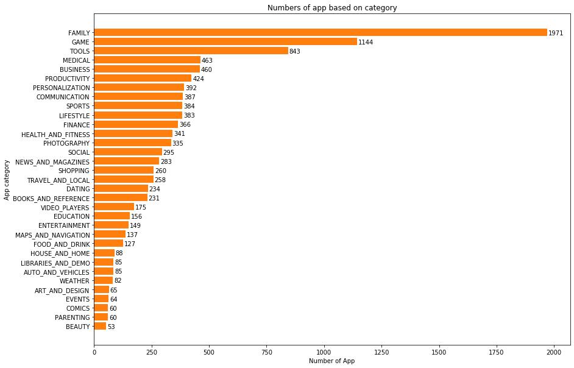

```python
plt.figure(figsize=(14,10))
ax = plt.subplot()
y = df_clean['category'].value_counts().index[::-1]
w = df_clean['category'].value_counts()[::-1]
ax.barh(y = y, width=w)
ax.barh(y = y, width=w)
plt.title('Numbers of app based on category')
plt.xlabel('Number of App')
plt.ylabel('App category')
for idx, val in enumerate(w):
    ax.text(val + 5, idx - .25, str(val), color='black')
```

*The category with highest popularity is FAMILY with 1971 apps which is far different compare to the second which is GAME with 1144 apps. The least popular category in the dataset given is BEAUTY with only 53 apps.*

#### What is the portion of free apps and paid apps?

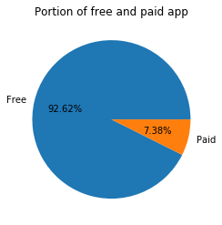

```python
df = df_clean.groupby('type').agg('count').reset_index()
plt.pie(df.app_name, labels=df.type, autopct='%1.2f%%')
plt.title("Portion of free and paid app")
```

92.62% is free apps and 7.38% is paid apps

#### Which category is most popular based on app type?

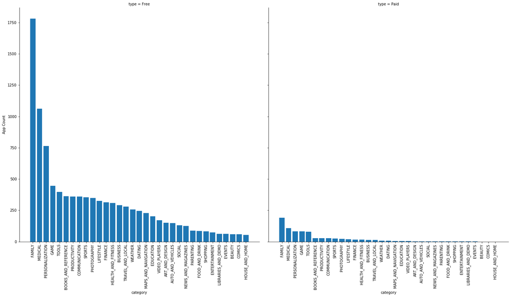

```python
df = df_clean.groupby(['type', 'category']).agg('count').sort_values('app_name', ascending=False).reset_index()
df = df[['type', 'category', 'app_name']]
df = df.rename(columns={'app_name': "App Count"})
g = sns.FacetGrid(data=df, col='type', size=10, margin_titles=True, dropna=False)
g.map(plt.bar, 'category', 'App Count')
g.set_xticklabels(rotation=90)
```

*The portion of apps for both Free and Paid have a almost similar distribution. Still FAMILY is the most popular category for both Free and Paid app. For Paid app, there is 0 app in category BEAUTY, COMICS and HOUSE_AND_HOME.*

#### What is the compatibility of the apps toward Android version?

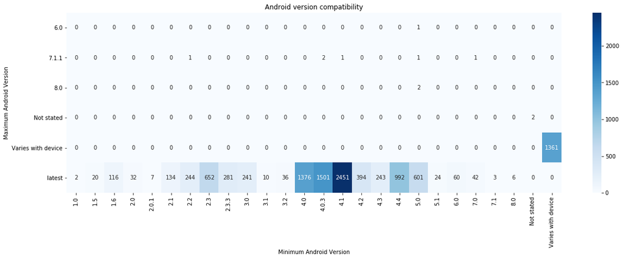

```python
df = df_clean.groupby(['min_android_ver', 'max_android_ver']).agg('count').add_suffix('_count').reset_index()
df = df[['min_android_ver', 'max_android_ver', 'app_name_count']]
df.loc[df.app_name_count.isna(), 'app_name_count'] = 0

plt.figure(figsize=(20,6))
sns.heatmap(df.pivot(index='max_android_ver', columns='min_android_ver', values='app_name_count'), cmap='Blues', annot=True, fmt=".0f")
plt.title("Android version compatibility")
plt.ylabel("Maximum Android Version")
plt.xlabel("Minimum Android Version")
```

#### What is the relationship between number of review and rating?

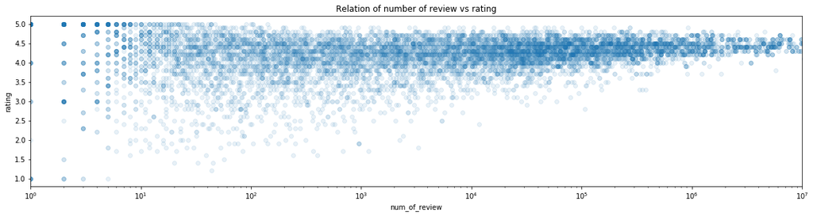

```python
plt.figure(figsize=(20,10))
plt.subplot(2,1,1)
sns.regplot(data=df_clean, x='num_of_review', y='rating', scatter_kws={'alpha':0.1}, fit_reg=False)
plt.xscale('log')
plt.xlim((1, 10000000))
plt.title("Relation of number of review vs rating")
```

*With this chart, it wasn't showing any strong relation between number of review and rating. But it shows most of the apps are fall between 4.0 to 4.5 of its rating. As the observation, with higher number of review there is low probability of getting low rating.*